# DS 202, Homework 1

January 25, 2018

### Useful Functions:

The below functions prove incredibly useful when initially exploring a data set. Personally, I use them to familiarize myself with the data and its types which makes working with the data much easier. They also serve as good tools to check if your data is ready for more rigorouos analysis.

1. summary()
2. typeof()
3. dim()
4. View()
5. str()

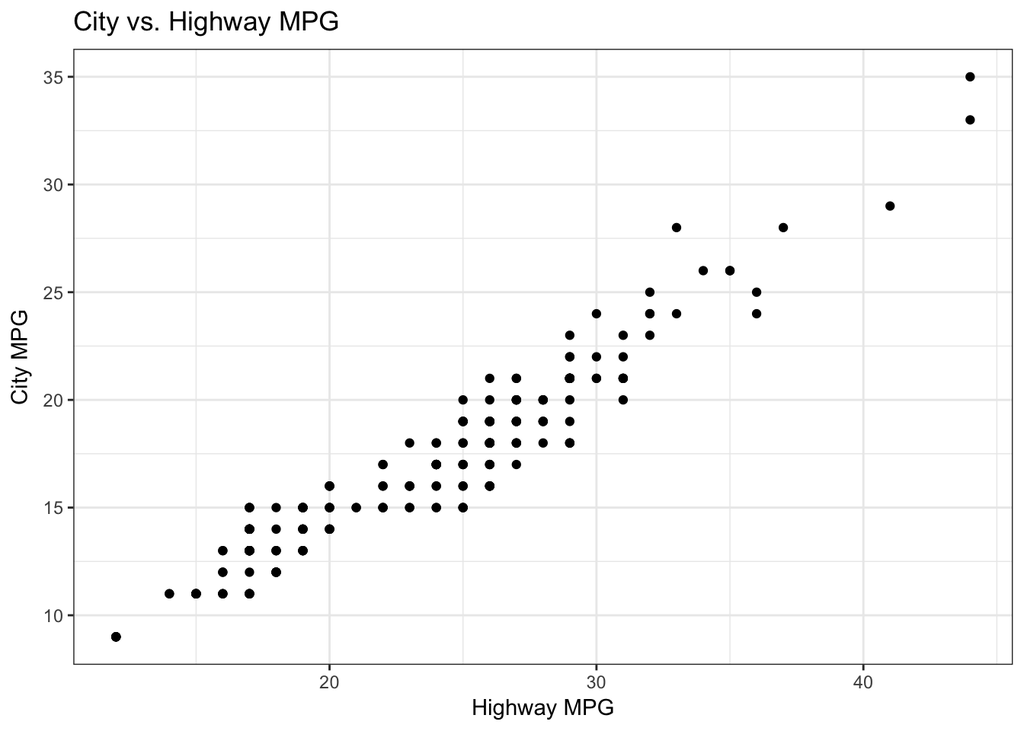

### Scatter Plot Analysis:

From the above plot, we can see that highway mpg and city mpg share a positive, strong, linear relationship, with possibly two outliers in the xy direction. However, it is apparent the number of data points in our plot are not equal to the number of observations in our data set. This is because multiple observations share the same values for both of these features, thus some points are laid on top of one another. This will be adressed in the graph below and may change our earlier mentioned comments on the relationship between highway mpg and city mpg.

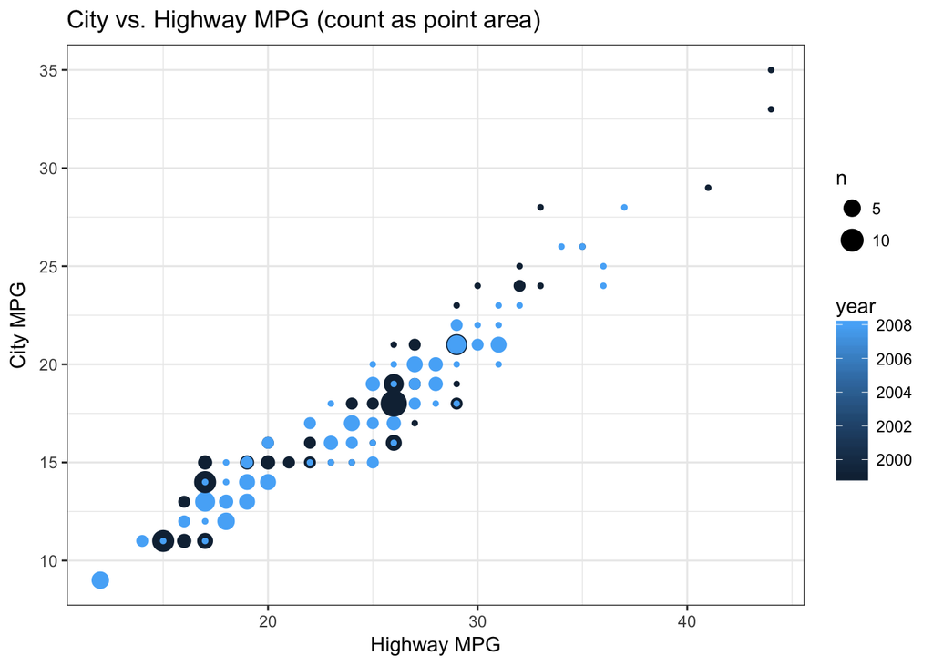

### Scatter Plot Analysis:

In the above plot, we have addressed the issue mentioned in our analysis of the previous plot. This plot addresses overplotting, by taking a count of equal observations for each of our two features and then maps that count to the corresponding point’s area. In short, the bigger the point, the greater number of observations that share those highway mpg and city mpg values. Additionally, our characterization of the relationshp between these features has not changed since this adjustment.For curiosities sake, we have also color coded our points by year to better understand our outlying data. In turn, we see that our outliers belong to vehicles from 1999. I find it very peculiar the older cars boast the maximum fuel efficiencies.

### Adding European Standard Columns:

```r
#Adding a column to our dataframe containing city mpg converted to European standard
mpg_df$cty_converted <- mpg_df$cty * 235.215
#Adding a column to our dataframe containing highway mpg converted to European standard
mpg_df$hwy_converted <- mpg_df$hwy * 235.215
```

In the code above, we simply added a column to our data frame with city mpg and highway mpg converted to european standards. Since 1 U.S. mile/gal = 235.215 L/100km, each row of both highway and city mpg columns were simply timesd by the above conversion.

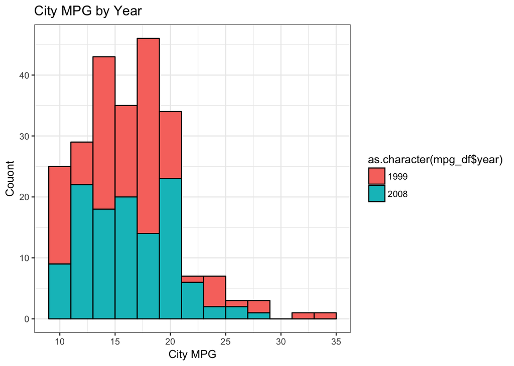

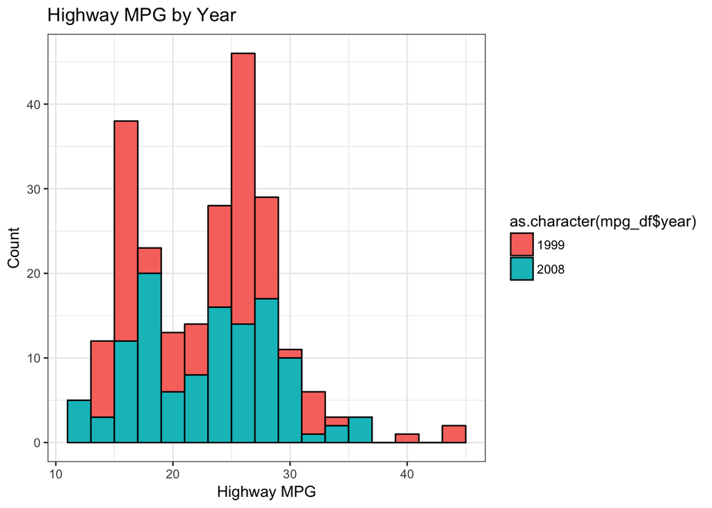

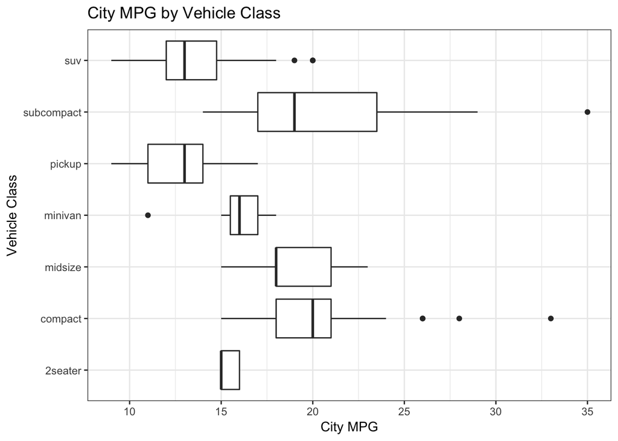

### Boxplot Analysis:

From the boxplot above, we can clearly see that SUVs and Pickups have the worst fuel efficiency in the city, with a median City MPG of rougly 13mpg. Subcompact cars offer the widest range of fuel efficiencies and also the highest fuel efficiency, not including outliers; though, compact cars offer the highest median fuel efficiency. More generally, 2seater and midsize vehicles display heavy skewedness, while most other classes appear to be more symmetricaly distriubtued, that is by no means to say they are perfectly, symmetrically distributed.